# P2_Investigate_A_Dataset

- Author: Rashid Kazmi
- Date: 04/03/2017

## 1. Introduction

## 2. Brainstorm Questions

## 3. Data Wrangling

- 3.1 Data Loading
- 3.2 Feature Engineering
- 3.3 Data Cleaning
- 3.4 Missing Values
- 3.5 Feature Engineering: Round 2
- 3.6 Feature Selection
- 3.7 Feature's Relationships

## 4. Data Exploration

- 4.1 Passengers Gender
- 4.2 Passengers Gender by Class
- 4.3 Passengers Gender - Child/Adult (Male or Female)
- 4.4 Passengers Age
- 4.5 Passengers Cabin/Deck
- 4.6 Passengers Deck Levels Vs Fare
- 4.7 Passengers Deck Levels Vs Survivour
- 4.8 Passengers Fare Vs Survivour
- 4.9 Passengers Embarked Cities
- 4.10 Passengers Traveling Alone/Families
- 4.11 What factors helped someone survive the sinking?
- 4.12 Passengers Survived
- 4.13 Passengers Survival Based on Traveling Alone versus with Family
- 4.14 Passengers Survived Vs Pclass
- 4.15 Passengers Survived Vs Pclass - Child/Adult (Male or Female)
- 4.16 Passengers Survived Vs Age - Pclass
- 4.17. Passengers Survived Vs Age - Sex

## 5. Conclusions

## 6. Limitations

## 6. Communication

# 1. Introduction

This is project as part of Data Analysis nanodegree. I have chosen to work with the Titanic dataset after spending some time poking around and looking at other resources made by Kagglers for inspiration. I focused on data analysis process as described during lectures of the course "Investigate a Dataset". I did a lot of data manipulation as well as some illustrative data visualisations along the way.

In this challenge, I will complete the analysis of what sorts of people were likely to survive. In particular, I will apply the tools of data analysis learned during the course to explore which passengers survived the tragedy.

# 2. Brainstorm Questions

First some basic questions:

1.) Who were the passengers on the Titanic? (Ages,Gender,Class,..etc)

2.) Where did the passengers come from?

3.) What deck were the passengers on and how does that relate to their class?

4.) Who was alone and who was with family?

5.) Do families sink or swim together?

Then we'll dig deeper, with a broader question:

6.) What factors helped someone survive the sinking?

# 3. Data Wrangling

# 3.1 Load and Check Data

```python
#Now let's open it with pandas
import pandas as pd

from pandas import Series, DataFrame

# Set up the Titanic csv file as a DataFrame
titanic_dat = pd.read_csv ('titanic-data.csv')

# Let's see a preview of the data
titanic_dat.head()
```

|  | PassengerId | Survived | Pclass | Name | Sex | Age | SibSp | Parch | Ticket | Fare | Cabin | Embarked |
| --- | --- | --- | --- | --- | --- | --- | --- | --- | --- | --- | --- | --- |
| 0 | 1 | 0 | 3 | Braund, Mr. Owen Harris | male | 22.0 | 1 | 0 | A/5 21171 | 7.2500 | NaN | S |
| 1 | 2 | 1 | 1 | Cumings, Mrs. John Bradley (Florence Briggs Th... | female | 38.0 | 1 | 0 | PC 17599 | 71.2833 | C85 | C |
| 2 | 3 | 1 | 3 | Heikkinen, Miss. Laina | female | 26.0 | 0 | 0 | STON/O2. 3101282 | 7.9250 | NaN | S |
| 3 | 4 | 1 | 1 | Futrelle, Mrs. Jacques Heath (Lily May Peel) | female | 35.0 | 1 | 0 | 113803 | 53.1000 | C123 | S |
| 4 | 5 | 0 | 3 | Allen, Mr. William Henry | male | 35.0 | 0 | 0 | 373450 | 8.0500 | NaN | S |

We've got a sense of our variables, their class type, and the first few observations of each. We know we're working with 891 observations of 12 variables. To make things a bit more explicit since a couple of the variable names aren't 100% illuminating, here's what we've got to deal with:

```python
# We can also get information of data
titanic_dat.info()
```

```
<class 'pandas.core.frame.DataFrame'>
RangeIndex: 891 entries, 0 to 890
Data columns (total 12 columns):
PassengerId    891 non-null int64
Survived       891 non-null int64
Pclass         891 non-null int64
Name           891 non-null object
Sex            891 non-null object
Age            714 non-null float64
SibSp          891 non-null int64
Parch          891 non-null int64
Ticket         891 non-null object
Fare           891 non-null float64
Cabin          204 non-null object
Embarked       889 non-null object
dtypes: float64(2), int64(5), object(5)
memory usage: 83.6+ KB
```

# 3.2. Feature Engineering

The first variable which catches my attention is age and sex name because we can break it down into additional meaningful variables which can feed predictions or be used in the creation of additional new variables. Let's do some feature engineering!

# 1. Age

```python
##  First let's make a function to sort through the sex
##  We'll treat anyone as under 16 as a child

def male_female_child (passenger):

    age, sex = passenger
    if age < 16 :
        return 'child'
    else:
        return sex
```

```python
## We'll define a new column called 'person', remember to specify axis=1 for columns and not index
## and then use the apply technique with a function to create a new column

titanic_dat['Person'] = titanic_dat[['Age', 'Sex']].apply(male_female_child, axis = 1)
titanic_dat.head()
```

[output not shown]

```python
print (titanic_dat[['Person', 'Survived']].groupby(['Person'], as_index = False).mean())
```

```
   Person  Survived
0   child  0.590361
1  female  0.756458
2    male  0.163873
```

# 2. Cabin

There’s probably some potentially useful information in the passenger cabin variable including about their Cabin. Let’s take a look.

```python
# Feature that tells whether a passenger had a cabin on the Titanic
titanic_dat['Has_Cabin'] = titanic_dat["Cabin"].apply(lambda x: 0 if type(x) == float else 1)
```

```python
print (titanic_dat[['Has_Cabin', 'Survived']].groupby(['Has_Cabin'], as_index = False).mean())
```

```
   Has_Cabin  Survived
0          0  0.299854
1          1  0.666667
```

# 3. Families

```python
## Create new feature FamilySize as a combination of SibSp and Parch
titanic_dat['FamilySize'] = titanic_dat['SibSp'] + titanic_dat['Parch'] + 1
```

```python
# Create new feature IsAlone from FamilySize
titanic_dat['IsAlone'] = 0
titanic_dat.loc[titanic_dat['FamilySize'] == 1, 'IsAlone'] = 1
```

```python
print (titanic_dat[['IsAlone', 'Survived']].groupby(['IsAlone'], as_index = False).mean())
```

```
   IsAlone  Survived
0        0  0.505650
1        1  0.303538
```

# 4. Family Size

```python
# Mapping FamilySize
def discretise_family_size(fam):
    if fam == 1:
        return 'singleton'
    elif fam < 5 and fam > 1:
        return 'small'
    else:
        return 'large'
```

```python
titanic_dat['FamilySizeD'] = titanic_dat[['SibSp']].applymap(discretise_family_size)
```

```python
print (titanic_dat[['FamilySizeD', 'Survived']].groupby(['FamilySizeD'], as_index = False).mean())
```

```
  FamilySizeD  Survived
0       large  0.338710
1   singleton  0.535885
2       small  0.322581
```

# 5. Passenger Title

We can break passenger name down into additional meaningful variables which can feed predictions or be used in the creation of additional new variables. For instance, passenger title is contained within the passenger name variable and we can use it to represent title.

```python
import re as re

def get_title(name):
    title_search = re.search(' ([A-Za-z]+)\.', name)

    # If the title exists, extract and return it.|
    if title_search:
        return title_search.group(1)
    return ""
```

```python
titanic_dat['Title'] = titanic_dat['Name'].apply(get_title)
```

```python
#titanic_dat.head()
```

```python
# Group all non-common titles into one single grouping "Rare"
titanic_dat['Title'] = titanic_dat['Title'].replace(['Lady', 'Countess','Capt', 'Col','Don', 'Dr',
                                             'Major', 'Rev', 'Sir', 'Jonkheer', 'Dona'], 'Rare')

titanic_dat['Title'] = titanic_dat['Title'].replace('Mlle', 'Miss')
titanic_dat['Title'] = titanic_dat['Title'].replace('Ms', 'Miss')
titanic_dat['Title'] = titanic_dat['Title'].replace('Mme', 'Mrs')
```

```python
# titanic_dat.head()
```

```python
print (titanic_dat[['Survived', 'Title']].groupby(['Title'], as_index = False).mean())
```

```
    Title  Survived
0  Master  0.575000
1    Miss  0.702703
2      Mr  0.156673
3     Mrs  0.793651
4    Rare  0.347826
```

# 3.3. Data Cleaning

```python
## Make Copy of Orignal DataFrame
titanic_dat_Original = titanic_dat.copy(deep=True)
titanic_dat_Original_1 = titanic_dat.copy(deep=True)
titanic_dat_1 = titanic_dat.copy(deep=True)
```

```python
titanic_dat_1.head()
```

|  | PassengerId | Survived | Pclass | Name | Sex | Age | SibSp | Parch | Ticket | Fare | Cabin | Embarked | Person | Has_Cabin | FamilySize | IsAlone | FamilySizeD | Title |
| --- | --- | --- | --- | --- | --- | --- | --- | --- | --- | --- | --- | --- | --- | --- | --- | --- | --- | --- |
| 0 | 1 | 0 | 3 | Braund, Mr. Owen Harris | male | 22.0 | 1 | 0 | A/5 21171 | 7.2500 | NaN | S | male | 0 | 2 | 0 | singleton | Mr |
| 1 | 2 | 1 | 1 | Cumings, Mrs. John Bradley (Florence Briggs Th... | female | 38.0 | 1 | 0 | PC 17599 | 71.2833 | C85 | C | female | 1 | 2 | 0 | singleton | Mrs |
| 2 | 3 | 1 | 3 | Heikkinen, Miss. Laina | female | 26.0 | 0 | 0 | STON/O2. 3101282 | 7.9250 | NaN | S | female | 0 | 1 | 1 | large | Miss |
| 3 | 4 | 1 | 1 | Futrelle, Mrs. Jacques Heath (Lily May Peel) | female | 35.0 | 1 | 0 | 113803 | 53.1000 | C123 | S | female | 1 | 2 | 0 | singleton | Mrs |
| 4 | 5 | 0 | 3 | Allen, Mr. William Henry | male | 35.0 | 0 | 0 | 373450 | 8.0500 | NaN | S | male | 0 | 1 | 1 | large | Mr |

# 3.4. Missing Values

### Missing Values Imputations :

Now we're ready to start exploring missing data and rectifying it through imputation. There are a number of different ways we could go about doing this. Given the small size of the dataset, we probably should not opt for deleting either entire observations (rows) or variables (columns) containing missing values. We're left with the option of either replacing missing values with a sensible values given the distribution of the data, e.g., the mean, median or mode. Finally, we could go with prediction later on.

The age feature has some missing values. While there are many ways to fill these missing values, using the mean or median of the rest of the values is quite common in such cases. I have calculated the mean, the standard deviation of the Age column and use that value to populate the missing values.

The embarked feature has some missing value. I have filled those with the most occurred value ( 'S' ). I carried out some data visualisation e.g. box plots, kde plots (not shown here) to guide my decisions to impute values with mean/median.

```python
# We have plenty of missing values in this feature.
# Generate random numbers between (mean - std) and (mean + std).

#Now let's open it with pandas
import numpy as np

age_avg = titanic_dat_1['Age'].mean()
age_std = titanic_dat_1['Age'].std()
age_null_count = titanic_dat_1['Age'].isnull().sum()
age_null_random_list = np.random.randint(age_avg - age_std, age_avg + age_std, size = age_null_count)
titanic_dat_1['Age'][np.isnan(titanic_dat_1['Age'])] = age_null_random_list
titanic_dat_1['Age'] = titanic_dat_1['Age'].astype(int)

#titanic_dat_1['Age'].isnull().sum()

# Mapping Embarked
# Remove all NULLS in the Fare column and create a new feature CategoricalFare
titanic_dat_1['Embarked'] = titanic_dat_1['Embarked'].fillna('S')
titanic_dat_1['Embarked'] = titanic_dat_1['Embarked'].map( {'S': 0, 'C': 1, 'Q': 2} ).astype(int)

## Remove all NULLS in the Cabin column
titanic_dat_1['Cabin'] = titanic_dat_1['Cabin'].fillna(0)

## Mapping Sex
titanic_dat_1['Sex'] = titanic_dat_1['Sex'].map( {'female': 0, 'male': 1} ).astype(int)

## Mapping titles
title_mapping = {"Mr": 1, "Miss": 2, "Mrs": 3, "Master": 4, "Rare": 5}
titanic_dat_1['Title'] = titanic_dat_1['Title'].map(title_mapping)
#titanic_dat_2['Title'] = titanic_dat_2['Title'].fillna(0)

## Mapping Fare
## Remove all NULLS in the Fare column and create a new feature CategoricalFare
titanic_dat_1['Fare'] = titanic_dat_1['Fare'].fillna(titanic_dat_1['Fare'].median())
titanic_dat_1.loc[titanic_dat_1['Fare'] <= 7.91, 'Fare']                                      = 0
titanic_dat_1.loc[(titanic_dat_1['Fare'] > 7.91) & (titanic_dat_1['Fare'] <= 14.454), 'Fare'] = 1
titanic_dat_1.loc[(titanic_dat_1['Fare'] > 14.454) & (titanic_dat_1['Fare'] <= 31), 'Fare']   = 2
titanic_dat_1.loc[titanic_dat_1['Fare'] > 31, 'Fare']                                         = 3
titanic_dat_1['Fare'] = titanic_dat_1['Fare'].astype(int)

## Mapping Fare
titanic_dat_Original_1.loc[titanic_dat_Original['Fare'] <= 7.91, 'Fare']                                                = 0
titanic_dat_Original_1.loc[(titanic_dat_Original['Fare'] > 7.91) & (titanic_dat_Original_1['Fare'] <= 14.454), 'Fare']  = 1
titanic_dat_Original_1.loc[(titanic_dat_Original['Fare'] > 14.454) & (titanic_dat_Original_1['Fare'] <= 31), 'Fare']    = 2
titanic_dat_Original_1.loc[titanic_dat_Original['Fare'] > 31, 'Fare']                                                   = 3
#titanic_dat_Original['Fare'] = titanic_dat_Original['Fare'].astype(int)


## Mapping Age
titanic_dat_1.loc[titanic_dat_1['Age'] <= 16, 'Age']                                 = 0
titanic_dat_1.loc[(titanic_dat_1['Age'] > 16) & (titanic_dat_1['Age'] <= 32), 'Age'] = 1
titanic_dat_1.loc[(titanic_dat_1['Age'] > 32) & (titanic_dat_1['Age'] <= 48), 'Age'] = 2
titanic_dat_1.loc[(titanic_dat_1['Age'] > 48) & (titanic_dat_1['Age'] <= 64), 'Age'] = 3
titanic_dat_1.loc[titanic_dat_1['Age'] > 64, 'Age']                                  = 4
```

```python
# Summary Statistics of the data
titanic_dat_1.describe()
```

|  | PassengerId | Survived | Pclass | Sex | Age | SibSp | Parch | Fare | Embarked | Has_Cabin | FamilySize | IsAlone | Title |
| --- | --- | --- | --- | --- | --- | --- | --- | --- | --- | --- | --- | --- | --- |
| count | 891.000000 | 891.000000 | 891.000000 | 891.000000 | 891.000000 | 891.000000 | 891.000000 | 891.000000 | 891.000000 | 891.000000 | 891.000000 | 891.000000 | 891.000000 |
| mean | 446.000000 | 0.383838 | 2.308642 | 0.647587 | 1.353535 | 0.523008 | 0.381594 | 1.505051 | 0.361392 | 0.228956 | 1.904602 | 0.602694 | 1.728395 |
| std | 257.353842 | 0.486592 | 0.836071 | 0.477990 | 0.842439 | 1.102743 | 0.806057 | 1.118148 | 0.635673 | 0.420397 | 1.613459 | 0.489615 | 1.030039 |
| min | 1.000000 | 0.000000 | 1.000000 | 0.000000 | 0.000000 | 0.000000 | 0.000000 | 0.000000 | 0.000000 | 0.000000 | 1.000000 | 0.000000 | 1.000000 |
| 25% | 223.500000 | 0.000000 | 2.000000 | 0.000000 | 1.000000 | 0.000000 | 0.000000 | 0.500000 | 0.000000 | 0.000000 | 1.000000 | 0.000000 | 1.000000 |
| 50% | 446.000000 | 0.000000 | 3.000000 | 1.000000 | 1.000000 | 0.000000 | 0.000000 | 2.000000 | 0.000000 | 0.000000 | 1.000000 | 1.000000 | 1.000000 |
| 75% | 668.500000 | 1.000000 | 3.000000 | 1.000000 | 2.000000 | 1.000000 | 0.000000 | 2.000000 | 1.000000 | 0.000000 | 2.000000 | 1.000000 | 2.000000 |
| max | 891.000000 | 1.000000 | 3.000000 | 1.000000 | 4.000000 | 8.000000 | 6.000000 | 3.000000 | 2.000000 | 1.000000 | 11.000000 | 1.000000 | 5.000000 |

# 3.5. Feature Engineering: Round 2

# Deck Levels

Notice we only need the first letter of the deck to classify its level (e.g. A,B,C,D,E,F,G)

```python
# Get first letter of a string from column "Deck"
## Cast the dtype of the col to str and you can perform vectorised slicing calling str:

titanic_dat_1['Deck_Levels'] = titanic_dat_1['Cabin'].astype(str).str[0]

#titanic_dat_1['Deck_Levels'] = titanic_dat_1['Deck_Levels'].fillna(0)
```

```python
 titanic_dat_1.head(2)
```

|  | PassengerId | Survived | Pclass | Name | Sex | Age | SibSp | Parch | Ticket | Fare | Cabin | Embarked | Person | Has_Cabin | FamilySize | IsAlone | FamilySizeD | Title | Deck_Levels |
| --- | --- | --- | --- | --- | --- | --- | --- | --- | --- | --- | --- | --- | --- | --- | --- | --- | --- | --- | --- |
| 0 | 1 | 0 | 3 | Braund, Mr. Owen Harris | 1 | 1 | 1 | 0 | A/5 21171 | 0 | 0 | 0 | male | 0 | 2 | 0 | singleton | 1 | 0 |
| 1 | 2 | 1 | 1 | Cumings, Mrs. John Bradley (Florence Briggs Th... | 0 | 2 | 1 | 0 | PC 17599 | 3 | C85 | 1 | female | 1 | 2 | 0 | singleton | 3 | C |

# 3.6. Feature Selection

```python
titanic_dat_2 = titanic_dat_1.copy(deep=True)

drop_elements = ['PassengerId', 'Name', 'Ticket', 'Person', 'Cabin','SibSp', 'FamilySizeD']

titanic_dat_2 = titanic_dat_2.drop(drop_elements, axis = 1)

titanic_dat_2.head()
```

|  | Survived | Pclass | Sex | Age | Parch | Fare | Embarked | Has_Cabin | FamilySize | IsAlone | Title | Deck_Levels |
| --- | --- | --- | --- | --- | --- | --- | --- | --- | --- | --- | --- | --- |
| 0 | 0 | 3 | 1 | 1 | 0 | 0 | 0 | 0 | 2 | 0 | 1 | 0 |
| 1 | 1 | 1 | 0 | 2 | 0 | 3 | 1 | 1 | 2 | 0 | 3 | C |
| 2 | 1 | 3 | 0 | 1 | 0 | 1 | 0 | 0 | 1 | 1 | 2 | 0 |
| 3 | 1 | 1 | 0 | 2 | 0 | 3 | 0 | 1 | 2 | 0 | 3 | C |
| 4 | 0 | 3 | 1 | 2 | 0 | 1 | 0 | 0 | 1 | 1 | 1 | 0 |

# 3.7. Feature's Relationships

Often we have features that are highly correlated and thus provide redundant information. By eliminating highly correlated features we can avoid a predictive bias for the information contained in these features. This also shows us, that when we want to make statements about the of specific features, we need to keep in mind that just because they are suitable to predicting an outcome they are not necessarily causal - they could simply be correlated with causal factors. This could be very important criterion in fitting predictive models late in the course.

```python
# Let's import what we'll need for the analysis and visualisation
import numpy as np
import matplotlib.pyplot as plt
import seaborn as sns
%matplotlib inline
```

Nontheless, correlations between all features are calculated and visualised. We can see correlations varied among individual features. The corrlation between sex and Surivied passengers is cosiderably high. However, direction of the correlation is negatice. Whic is quite understandable as there is marked difference for surival between males and demales. We will see it in later sectoions.

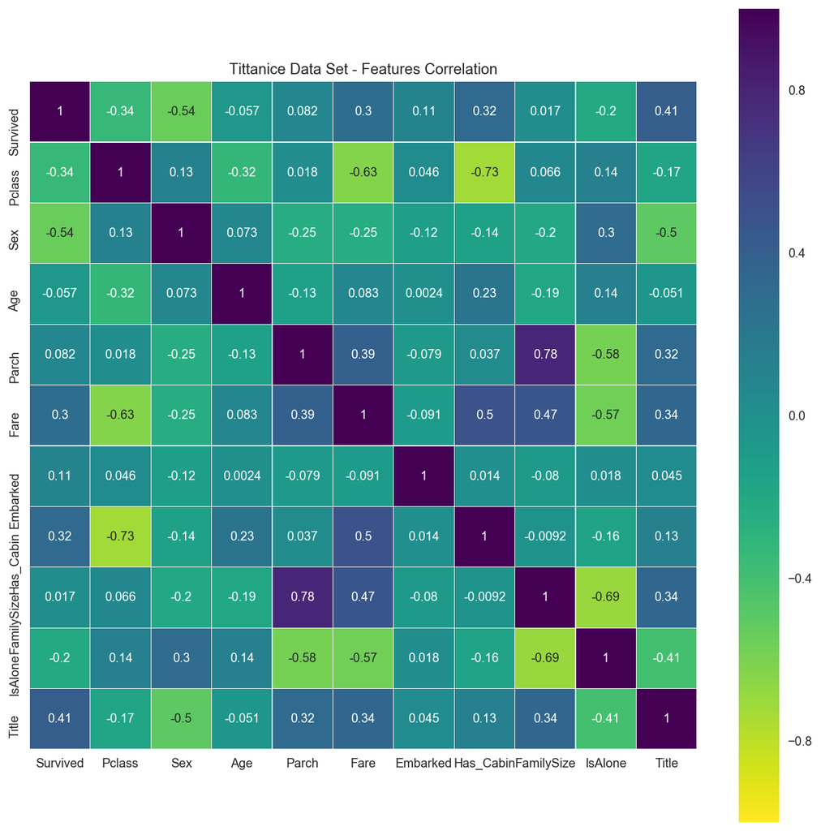

```python
%config InlineBackend.figure_format = 'retina'

colormap = plt.cm.viridis_r
plt.figure(figsize=(12,12))

cor = sns.heatmap(titanic_dat_2.corr(),linewidths=0.1,vmax=1.0, square=True, cmap=colormap, linecolor='white', annot=True)
cor.set(title='Tittanice Data Set - Features Correlation')
```

# 4. Data Exploration

# 4.1. Passengers Gender

Passengers geneder is considered a significant factor to consider due to the tradtional belief that in times of emergencies that deal with the sinking of a ship women and children were considered priority to be put on life boats to be brought to safety. So the expectation would be that males would be the majority of the deaths on the titanic. So the first factor to be considered is to consider how many females and males were on the titanic.

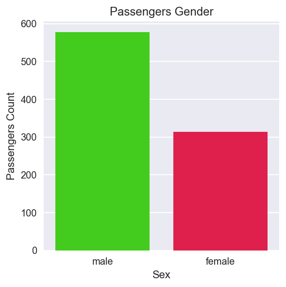

```python
# Let's try the factorplot again!
%config InlineBackend.figure_format = 'retina'

pg = sns.factorplot('Sex', data = titanic_dat_Original, palette = 'prism', kind = "count")
pg.set(title='Passengers Gender', xlabel = 'Sex', ylabel = 'Passengers Count')
```

# 4.2. Passengers Gender by Class

Going deeper we should consider the gender distribution in each of the Pclass which are a classification of socioeconomic distinctions of passengers in the titanic to see if there is a significant gender population in any of the 3 socialeconomic classes.

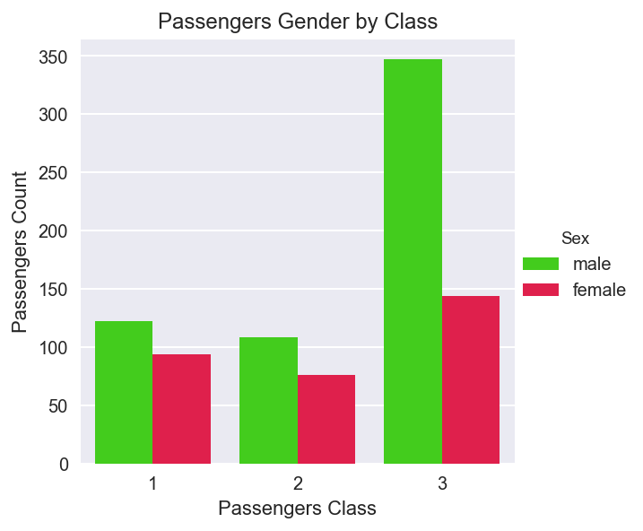

```python
# Let's try the factorplot again!
%config InlineBackend.figure_format = 'retina'

pgbyc = sns.factorplot('Pclass', data = titanic_dat_Original, palette = 'prism', hue = 'Sex', kind = "count")
pgbyc.set(title='Passengers Gender by Class', xlabel = 'Passengers Class', ylabel = 'Passengers Count')
```

# 4.3. Passengers Gender - Child/Adult (Male or Female)

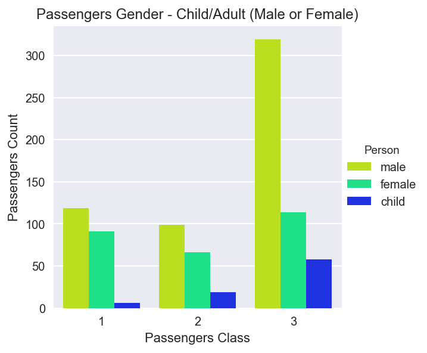

```python
# Let's try the factorplot again!
%config InlineBackend.figure_format = 'retina'

pgca = sns.factorplot('Pclass',data=titanic_dat_Original, palette = 'gist_rainbow', hue='Person',  kind = "count")
pgca.set(title='Passengers Gender - Child/Adult (Male or Female)', xlabel = 'Passengers Class', ylabel = 'Passengers Count')
```

# 4.4. Passengers Age

Interesting, quite a bit of children in 3rd class and not so many in 1st! How about we create a distribution of the ages to get a more precise picture of the who the passengers were.

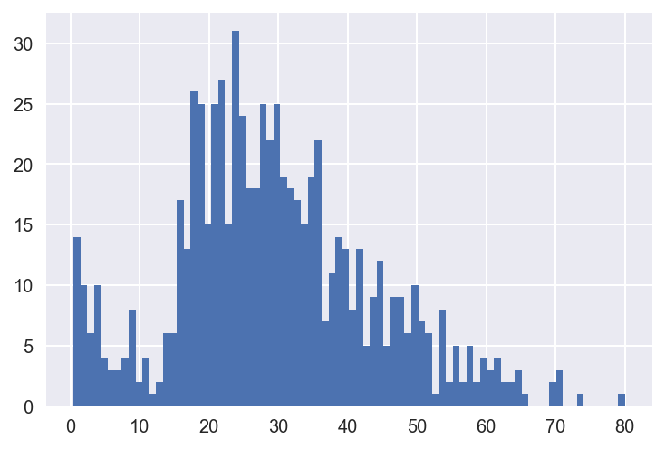

```python
%config InlineBackend.figure_format = 'retina'

titanic_dat_Original['Age'].hist(bins=80)
```

```python
# We could also do get a quick comaprison of male, female and child
titanic_dat['Person'].value_counts()
```

[output not shown]

# 4.5. Passengers Cabin/Deck

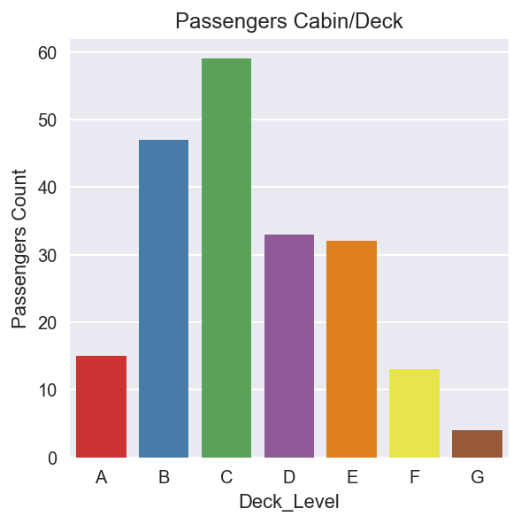

```python
## What deck were the passengers on and how does that relate to their class?
%config InlineBackend.figure_format = 'retina'

titanic_dat_1 = titanic_dat_1[titanic_dat_1.Deck_Levels != 'T']
#titanic_dat_1 = titanic_dat_Original[titanic_dat_1.Deck_Levels != 0]
axix_order = ['A','B','C', 'D', 'E', 'F', 'G']

pcd = sns.factorplot('Deck_Levels', data=titanic_dat_1, palette='Set1', x_order=axix_order, kind = "count")
pcd.set(title='Passengers Cabin/Deck', xlabel = 'Deck_Level', ylabel = 'Passengers Count')
```

# 4.6. Passengers Deck Levels Vs Fare

As mentioned above its good idea to have essence of passeneger cabins to surviviablity. Nonthless, we can also see how cabin were associated with fare. Though, we have a lot of missing information fro passnger deck. We can still get idea of passegners distribution in different decks and it can least give us an idea if the location of the cabin or cabin and fare had any influence on the surviour.

Fair and deck levels does not show a clear relationship between two features. Which could be partly due a lot of missing data. Or there can be some other unseen factors.

```python
## Function to convert fares prices into catagories
def convert_far_in_cat(fare):
    if fare == 0:
        return 'low'
    elif fare == 1:
        return 'medium'
    elif fare == 2:
        return 'high'
    else:
        return 'very high'
```

```python
titanic_dat_1['FareD'] = titanic_dat_1[['Fare']].applymap(convert_far_in_cat)
```

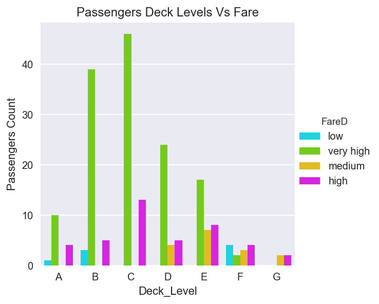

```python
## What deck were the passengers on and how does that relate to their class?
%config InlineBackend.figure_format = 'retina'

titanic_dat_1["Survivour"] = titanic_dat_1.Survived.map({0: "No", 1: "Yes"})

pcdlf = sns.factorplot('Deck_Levels', data=titanic_dat_1, palette = 'gist_ncar', hue = 'FareD',x_order =axix_order, kind = 'count')

pcdlf.set(title='Passengers Deck Levels Vs Fare', xlabel = 'Deck_Level', ylabel = 'Passengers Count')
```

# 4.7. Passengers Deck Levels Vs Survivour

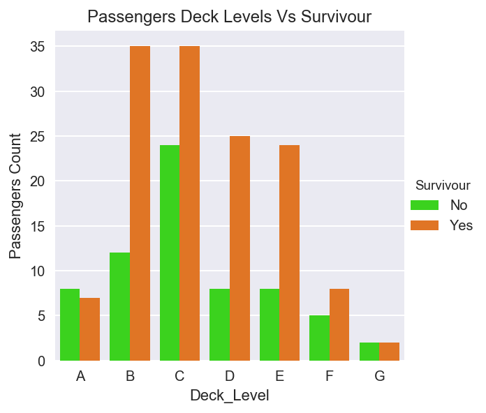

```python
## What deck were the passengers on and how does that relate to their class?
%config InlineBackend.figure_format = 'retina'

pcdls = sns.factorplot('Deck_Levels', data=titanic_dat_1, hue = 'Survivour',x_order =axix_order, palette = 'gist_ncar', kind = 'count')
pcdls.set(title='Passengers Deck Levels Vs Survivour', xlabel = 'Deck_Level', ylabel = 'Passengers Count')
```

# 4.8. Passengers Fare Vs Survivour

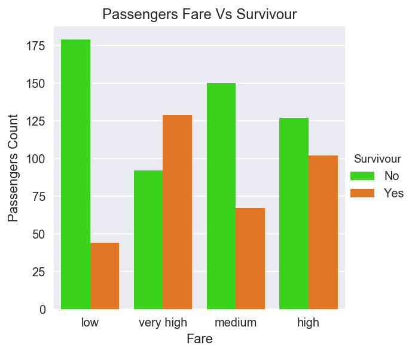

```python
# What deck were the passengers on and how does that relate to their class?
%config InlineBackend.figure_format = 'retina'

pfs = sns.factorplot('FareD', data=titanic_dat_1, hue = 'Survivour',palette = 'gist_ncar', kind = 'count')

pfs.set(title='Passengers Fare Vs Survivour', xlabel = 'Fare', ylabel = 'Passengers Count')
```

# 4.9. Passengers Embarked Cities

Note here that the Embarked column has C,Q,and S values. Reading about the project on Kaggle we note that these stand for Cherbourg, Queenstown, Southhampton.

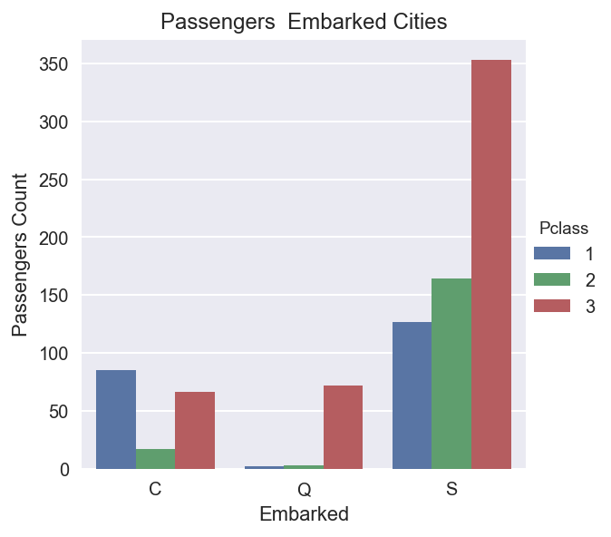

```python
# Now we can make a quick factorplot to check out the results, note the x_order argument, used to deal with NaN values
%config InlineBackend.figure_format = 'retina'

pec = sns.factorplot('Embarked',data=titanic_dat_Original_1,hue='Pclass',x_order=['C','Q','S'], kind = "count")

pec.set(title='Passengers  Embarked Cities', xlabel = 'Embarked', ylabel = 'Passengers Count')
```

An interesting find here is that in Queenstown, almost all the passengers that boarded there were 3rd class. It would be intersting to look at the economics of that town in that time period for further investigation.

## Now let's take a look at the 4th question:

**Who was alone and who was with family?**

# 4.10. Passengers Traveling Alone/Families

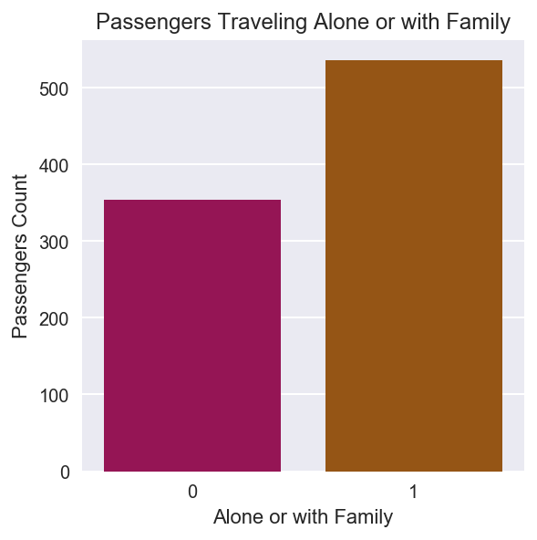

```python
# Now let's get a simple visualization!
%config InlineBackend.figure_format = 'retina'

ptaf = sns.factorplot('IsAlone',data=titanic_dat_1, palette='brg', kind = "count")
ptaf.set(title='Passengers Traveling Alone or with Family', xlabel = 'Alone or with Family', ylabel = 'Passengers Count')
```

# 4.11. What factors helped someone survive the sinking?

So far we've throughly analysed the data let's go ahead and take a look at the most interesting (and open-ended) question:

# 4.12. Passengers Survived

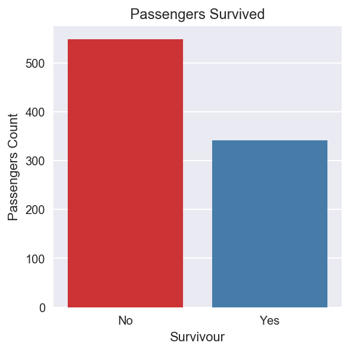

```python
# Let's start by creating a new column for legibility purposes through mapping (Lec 36)
%config InlineBackend.figure_format = 'retina'

titanic_dat["Survivour"] = titanic_dat_1.Survived.map({0: "No", 1: "Yes"})

# Let's just get a quick overall view of survied vs died.
ps = sns.factorplot('Survivour',data=titanic_dat_1,palette='Set1', kind = "count" )
ps.set(title='Passengers Survived', xlabel = 'Survivour', ylabel = 'Passengers Count')
```

# 4.13. Passengers Survival Based on Traveling Alone versus with Family

We can see that there’s a survival penalty to singletons and those with family sizes above 4. We can collapse this variable into three levels which will be helpful since there are comparatively fewer large families. Let’s create a discretized family size variable.

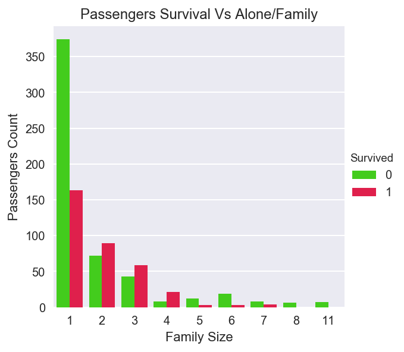

```python
pssb = sns.factorplot('FamilySize', data=titanic_dat, hue = 'Survived', palette= 'prism', kind = "count")
pssb.set(title='Passengers Survival Vs Alone/Family', xlabel = 'Family Size', ylabel = 'Passengers Count')
```

# 4.14. Passengers Survived Vs Pclass

So quite a few more people died than those who survived. Let's see if the class of the passengers had an effect on their survival rate, since the movie Titanic popularized the notion that the 3rd class passengers did not do as well as their 1st and 2nd class counterparts.

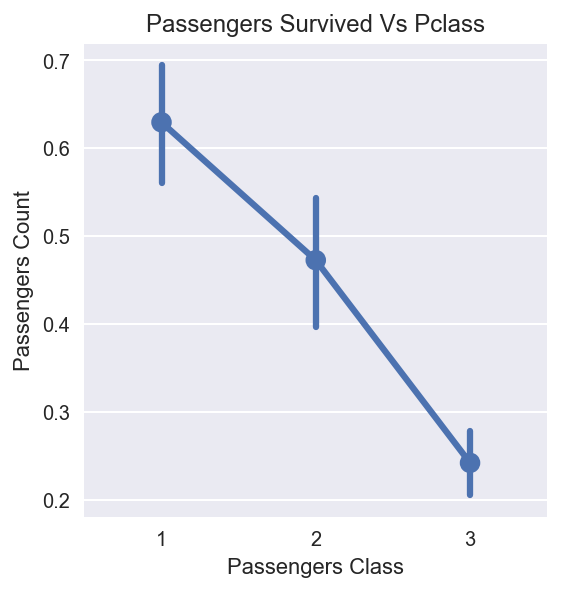

```python
# Let's use a factor plot again, but now considering class
%config InlineBackend.figure_format = 'retina'

psp = sns.factorplot('Pclass','Survived',data=titanic_dat)
psp.set(title='Passengers Survived Vs Pclass', xlabel = 'Passengers Class', ylabel = 'Passengers Count')
```

Look like survival rates for the 3rd class are substantially lower! But maybe this effect is being caused by the large amount of men in the 3rd class in combination with the women and children first policy. Let's use 'hue' to get a clearer picture on this.

# 4.15. Passengers Survived Vs Pclass - Child/Adult (Male or Female)

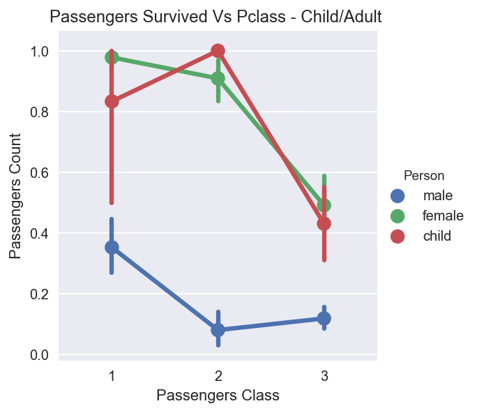

```python
# Let's use a factor plot again, but now considering class and gender

%config InlineBackend.figure_format = 'retina'

pscamf = sns.factorplot('Pclass','Survived',hue='Person',data=titanic_dat)
pscamf.set(title='Passengers Survived Vs Pclass - Child/Adult ', xlabel = 'Passengers Class', ylabel = 'Passengers Count')
```

# 4.16. Passengers Survived Vs Age - Pclass

From this data it looks like being a male or being in 3rd class were both not favourable for survival. Even regardless of class the result of being a male in any class dramatically decreases your chances of survival. But what about age? Did being younger or older have an effect on survival rate?

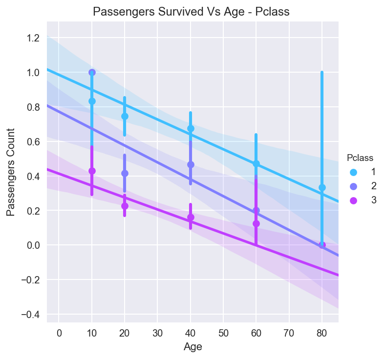

```python
# Let's use a linear plot on age versus survival using hue for class seperation
%config InlineBackend.figure_format = 'retina'

generations=[10,20,40,60,80]
psap = sns.lmplot('Age','Survived',hue='Pclass',data=titanic_dat,palette='cool',x_bins=generations)
psap.set(title='Passengers Survived Vs Age - Pclass ', xlabel = 'Age', ylabel = 'Passengers Count')
```

# # 4.17. Passengers Survived Vs Age - Sex

Interesting find on the older 1st class passengers! What about if we relate gender and age with the survival set?

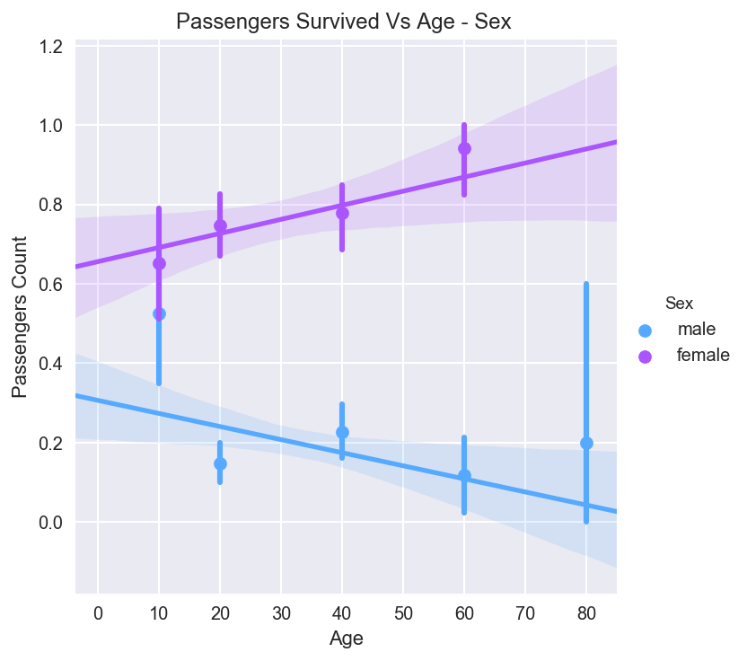

```python
%config InlineBackend.figure_format = 'retina'

psas = sns.lmplot('Age','Survived',hue='Sex',data=titanic_dat,palette='cool',x_bins=generations)
psas.set(title='Passengers Survived Vs Age - Sex ', xlabel = 'Age', ylabel = 'Passengers Count')
```

# Conclusions::

When looking at the passengers’ data we see that we can split it into specific groups based on age (Child and adult age groups), gender, embarked cities, location of cabins and passenger classes. When separating the passengers into these groups it allowed us to investigate survival for each of the groups and a combination of the groups that passengers match with.

# What next ?

We have just explored Titanic data set by data manipulation and visualisations. However, in order to back up our findings we need to carry out some sort of statistical tests so we can draw some sort of fairly straightforward conclusions from this data. For example being a woman, being in 1st class and being of a child all factors that could boost your chances of survival during this disaster. What we can do is to use predictive models to predict whether a given passenger would survive the disaster. This is where machine learning comes in: we will build a programme that learns from the sample data to predict whether a given passenger would survive.

- Good test set performance of a statistical learning method requires low variance as well as low squared bias. This is referred to as a trade-off because it is easy to obtain a method with extremely low bias but high variance or a method with very low variance but high bias. The challenge lies in finding a method for which both the variance and the squared bias are low. This trade-off is one of the most important recurring themes in data analysis process.
- Number of machine learning algorithms can be applied to data. Staring from some sort of simple models (linear model, logistic regression) to really advance level predictive models (Random Forest, Neural Network , SVM, Naive Bays etc..). Once we have number of models for our data set, we can look at the accuracy for all of our models. The best fitting model can be used for final interpretation of our dataset. This would enable of which above-mentioned factors/features finally contributed to survival of the passenger on titanic.
- Furhtermore, We can fine-tune the machine learning algorithms to achieve better accuracy on this data set, design our own statistical models using python, discover more fascinating stories of passengers whose survival does not match the model, and apply all of these techniques to any other data set. Someone rightly said **when it comes to machine learning, the possibilities are endless and the opportunities are titanic**.

# 6. Limitations

The conclusion made based on this analysis could be having some caveats.

# 7. Communication::

```
*I am thinking to communicate my results to Kaggle after review from Udacity to broader data science community.*
```